# CENG 4515 DATA SCIENCE AND ANALYTICS

Gizem Özgen - Gökhan Yasin Kaya

2023-01-08

## Importing libraries

```r
library(readxl)
library(dplyr)
library(plyr)
library(cluster)
library(ClusterR)
library(ggplot2)
library(tidyverse)
library(moments)
library(forcats)
library(gridExtra)
library(RColorBrewer)
library(rsample)
library(broom.mixed)
library(Metrics)
library(corrplot)
library(caret)
library(factoextra)
library(ggpubr)
library(rpart)
library(rpart.plot)
library(jtools)
library(devtools)
library(ggbiplot)
install_github("vqv/ggbiplot")
```

### 1. Please find your original dataset or datasets; and describe your data in the first step.

Our dataset is a multinational company Human Resources (HR) data which includes employee attributes. This dataset contains 14999 unique employee and 11 attribute of employees such as:

Emp_id = Employee Id satisfaction_level = Satisfaction of Employee from Company last_evaluation = Employee Id number_project = Number of the projects that an employee works average_montly_hours = Average Monthly hours of an employee Work_accident = True False value of question: “Is employeee had an accident?” left = True False value of question: “Is employeee left?” promotion_last_5years = True False value of question: “Is employeee get a promotion in last 5 years?” Department = Department of the Employee salary = Salary of the Employee (as: low,medium,high)

```r
data <- read_excel("HR_Employee_Data.xlsx")
glimpse(data,width = getOption("width"))
```

```
## Rows: 14,999
## Columns: 11
## $ Emp_Id                <chr> "IND02438", "IND28133", "IND07164", "IND30478", …
## $ satisfaction_level    <dbl> 0.38, 0.80, 0.11, 0.72, 0.37, 0.41, 0.10, 0.92, …
## $ last_evaluation       <dbl> 0.53, 0.86, 0.88, 0.87, 0.52, 0.50, 0.77, 0.85, …
## $ number_project        <dbl> 2, 5, 7, 5, 2, 2, 6, 5, 5, 2, 2, 6, 4, 2, 2, 2, …
## $ average_montly_hours  <dbl> 157, 262, 272, 223, 159, 153, 247, 259, 224, 142…
## $ time_spend_company    <dbl> 3, 6, 4, 5, 3, 3, 4, 5, 5, 3, 3, 4, 5, 3, 3, 3, …
## $ Work_accident         <dbl> 0, 0, 0, 0, 0, 0, 0, 0, 0, 0, 0, 0, 0, 0, 0, 0, …
## $ left                  <dbl> 1, 1, 1, 1, 1, 1, 1, 1, 1, 1, 1, 1, 1, 1, 1, 1, …
## $ promotion_last_5years <dbl> 0, 0, 0, 0, 0, 0, 0, 0, 0, 0, 0, 0, 0, 0, 0, 0, …
## $ Department            <chr> "sales", "sales", "sales", "sales", "sales", "sa…
## $ salary                <chr> "low", "medium", "medium", "low", "low", "low", …
```

### 2. Use “Exploratory data analysis”. Write down your comments.

Firstly, We chech our data to having a NA value or not.

```r
sum(is.na(data))
```

```
## [1] 0
```

Secondly, We transform categorical character columns into factors and scale the integers between 0-1

```r
transformedData <- preProcess(data, method = "range")
data <- predict(transformedData, data)
data <- transform(data, salary = as.integer(as.factor(salary)))
```

Then, We drop the “Emp_Id” column (no significant value).

```r
data <- data%>%
  select(-c(Emp_Id))
```

After that, Create a datafile to better visualise most departments.

```r
# Group data by department and summarize the count of each department
topEmployee <- data %>%
  group_by(Department) %>%
  dplyr::summarize(count = n()) %>%
  arrange(desc(count))

# Select the top 5 departments by count
top5Dep <- topEmployee[1:5, ]
```

Lastly, We print our dataset again.

```r
glimpse(data,width = getOption("width"))
```

```
## Rows: 14,999
## Columns: 10
## $ satisfaction_level    <dbl> 0.31868132, 0.78021978, 0.02197802, 0.69230769, …
## $ last_evaluation       <dbl> 0.265625, 0.781250, 0.812500, 0.796875, 0.250000…
## $ number_project        <dbl> 0.0, 0.6, 1.0, 0.6, 0.0, 0.0, 0.8, 0.6, 0.6, 0.0…
## $ average_montly_hours  <dbl> 0.2850467, 0.7757009, 0.8224299, 0.5934579, 0.29…
## $ time_spend_company    <dbl> 0.125, 0.500, 0.250, 0.375, 0.125, 0.125, 0.250,…
## $ Work_accident         <dbl> 0, 0, 0, 0, 0, 0, 0, 0, 0, 0, 0, 0, 0, 0, 0, 0, …
## $ left                  <dbl> 1, 1, 1, 1, 1, 1, 1, 1, 1, 1, 1, 1, 1, 1, 1, 1, …
## $ promotion_last_5years <dbl> 0, 0, 0, 0, 0, 0, 0, 0, 0, 0, 0, 0, 0, 0, 0, 0, …
## $ Department            <chr> "sales", "sales", "sales", "sales", "sales", "sa…
## $ salary                <int> 2, 3, 3, 2, 2, 2, 2, 2, 2, 2, 2, 2, 2, 2, 2, 2, …
```

### 3. Use some “visualization techniques” and talk about your data further

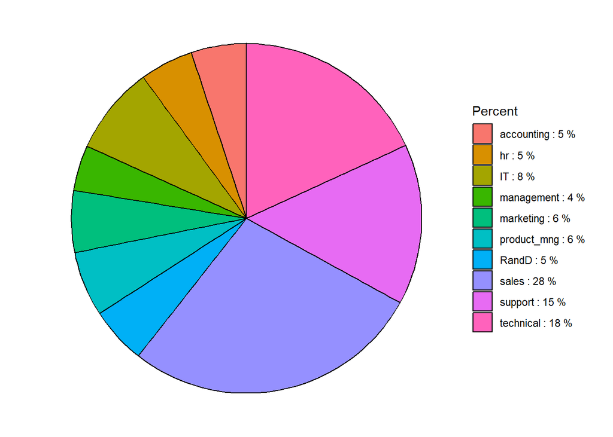

```r
employment_type_count<-data%>%
group_by(Department)%>%
dplyr::summarise(count=n())%>%
mutate(Percent = paste(Department,":",round(100*count/sum(count)), "%"))%>%
mutate(prop = count / sum(count) *100)

ggplot(employment_type_count, aes(x="", y=prop, fill=Percent)) +
  geom_bar(stat="identity", width=1, color="black") +
  coord_polar("y", start=0) +
  theme_void()
```

This graph contains all departments. It shows the percentages of employees by each department.

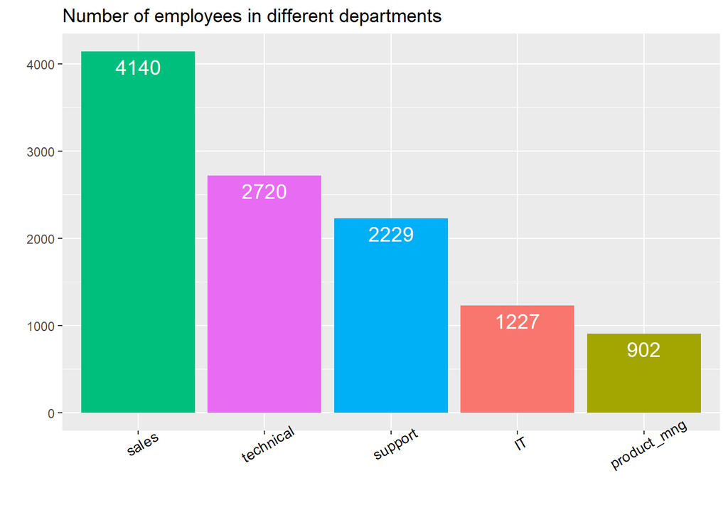

```r
ggplot(top5Dep) +
  geom_col(aes(x = reorder(Department, -count), y = count, fill = Department)) +
  geom_text(aes(x = reorder(Department, -count), y = count, label = count), vjust = 1.5, colour = "white", position = position_dodge(.9), size = 5) +
  ggtitle("Number of employees in different departments") +
  xlab("") +
  ylab("") +
  theme(axis.text.x = element_text(angle = 30, size = 10, color = "black", hjust = 0.5)) +
  theme(legend.position = "none")
```

There are 5 departments with the highest number of employees in the company. Based on this graph, the department with the most employees is the sales department, followed by the technical department.

### 4. Check your data for multicollinearity.

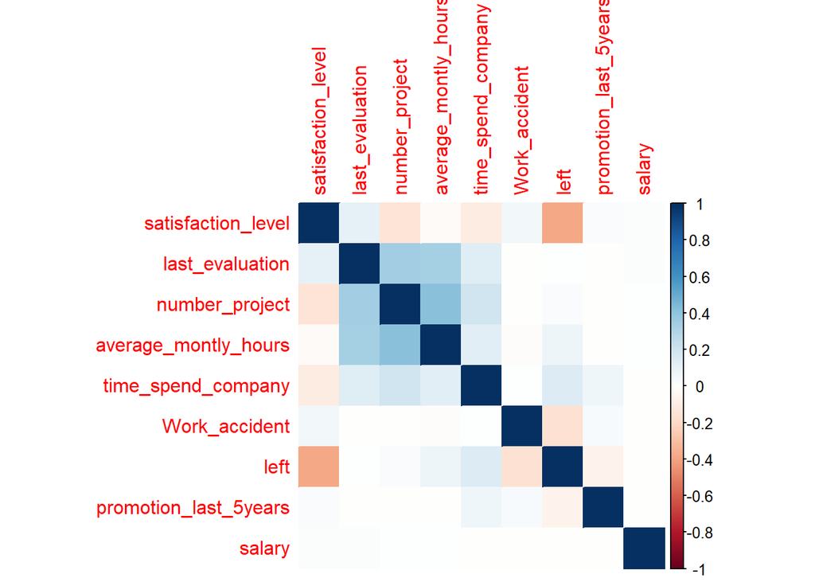

```r
data_cor<-data[, c(1:8, 10)]
cor <- cor(data_cor)
corrplot(cor, method = 'color')
```

In this correlation matrix, the darker the color, the stronger correlation is. We can say that average_monthly_hours and number_project has positive correlation, satisfaction_level and left has a negative but not strong correlation.

### 5. Apply PCA

```r
datapca <- prcomp(data_cor, scale=TRUE,center = TRUE)
#reverse the signs
datapca$rotation <- -1*datapca$rotation #eigenvectors in R point in the negative direction by default
head(datapca$rotation)
```

```
##                              PC1        PC2        PC3          PC4
## satisfaction_level   -0.18916086  0.6084103 -0.1442392  0.002025143
## last_evaluation       0.46380764  0.3118634 -0.1548850  0.017424116
## number_project        0.55705957  0.1219683 -0.0106627  0.023291069
## average_montly_hours  0.52562028  0.1779333 -0.1097887  0.034336941
## time_spend_company    0.33377147 -0.1177003  0.4409212 -0.054714112
## Work_accident        -0.06439211  0.2808987  0.4273870  0.032900192
##                               PC5         PC6         PC7         PC8
## satisfaction_level   -0.254121334  0.32261547 -0.24348487  0.29096526
## last_evaluation      -0.104336225  0.06469366 -0.52265596 -0.54805156
## number_project        0.096762382 -0.18884268  0.47347561 -0.24135584
## average_montly_hours  0.009167641 -0.25359580 -0.02333746  0.72134010
## time_spend_company   -0.042899061  0.79304840  0.16023409  0.09322204
## Work_accident         0.811963652 -0.06525810 -0.25275425  0.02940217
##                              PC9
## satisfaction_level    0.51053109
## last_evaluation      -0.27336728
## number_project        0.58880888
## average_montly_hours -0.30587487
## time_spend_company   -0.11048404
## Work_accident         0.07010533
```

```r
summary(datapca)
```

```
## Importance of components:
##                           PC1    PC2    PC3    PC4    PC5     PC6     PC7
## Standard deviation     1.3642 1.2102 1.0304 0.9995 0.9775 0.91951 0.84196
## Proportion of Variance 0.2068 0.1627 0.1180 0.1110 0.1062 0.09394 0.07877
## Cumulative Proportion  0.2068 0.3695 0.4875 0.5985 0.7046 0.79858 0.87735
##                            PC8     PC9
## Standard deviation     0.79150 0.69094
## Proportion of Variance 0.06961 0.05304
## Cumulative Proportion  0.94696 1.00000
```

We can see that the first principal component (PC1) has high values for number_project and average_montly_hours which indicates that this principal component describes the most variation in these variables.We can also see that the second principal component (PC2) has a high value for satisfaction_level, which indicates that this principle component places most of its emphasis on satisfaction levels of employees.

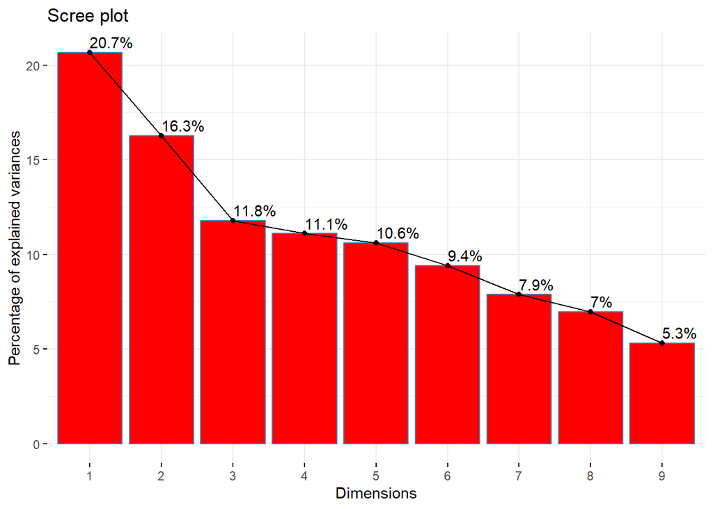

```r
fviz_eig(datapca, addlabels=TRUE, barfill = "red")
```

We can see that PC1 has the highest variance with 20.7%. PC1 and PC2 has the highest variance rates so we will use these two.

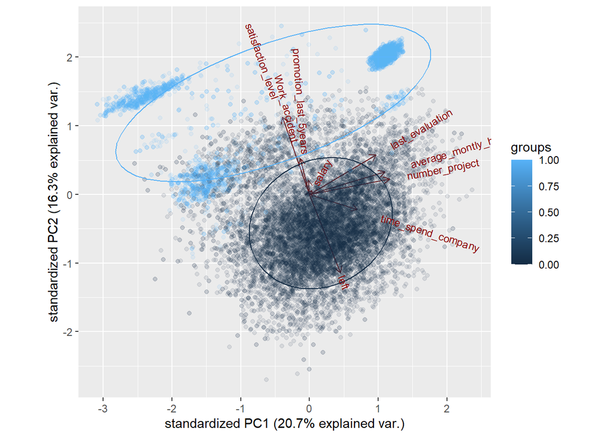

```r
ggbiplot(datapca,labels.size = 0,alpha=0.1,ellipse = TRUE,groups = data$left)
```

This biplot with labels for the data points removed and made semi-transparent (alpha=0.1) so that it would not appear confusing. It also includes ellipse overlays and groups the data points by left variable.

## 6.Apply Logistic Regression or Regression

### 6.A. Use appropriate functions and arguments

We split our dataset into two tables, trainSet and testSet, with 80% and 20% of the data, respectively.

```r
set.seed(241)
trainIndex <- createDataPartition(data$left, p = .8, list = FALSE)

trainSet <- data[trainIndex, ]
testSet <- data[-trainIndex, ]
modelLogistic <- glm(left~.,family="binomial", data=trainSet)
summary(modelLogistic)
```

```
##
## Call:
## glm(formula = left ~ ., family = "binomial", data = trainSet)
##
## Deviance Residuals:
##     Min       1Q   Median       3Q      Max
## -2.4184  -0.6786  -0.4309  -0.1477   3.1315
##
## Coefficients:
##                        Estimate Std. Error z value Pr(>|z|)
## (Intercept)            0.572945   0.154168   3.716 0.000202 ***
## satisfaction_level    -3.731186   0.098541 -37.864  < 2e-16 ***
## last_evaluation        0.480410   0.104601   4.593 4.37e-06 ***
## number_project        -1.594227   0.117225 -13.600  < 2e-16 ***
## average_montly_hours   0.881358   0.121211   7.271 3.56e-13 ***
## time_spend_company     1.921482   0.134889  14.245  < 2e-16 ***
## Work_accident         -1.528568   0.099376 -15.382  < 2e-16 ***
## promotion_last_5years -1.687754   0.280596  -6.015 1.80e-09 ***
## Departmenthr           0.145235   0.143898   1.009 0.312833
## DepartmentIT          -0.205707   0.132241  -1.556 0.119816
## Departmentmanagement  -0.807246   0.171708  -4.701 2.59e-06 ***
## Departmentmarketing   -0.111705   0.142393  -0.784 0.432758
## Departmentproduct_mng -0.299672   0.143000  -2.096 0.036117 *
## DepartmentRandD       -0.681839   0.160028  -4.261 2.04e-05 ***
## Departmentsales       -0.052734   0.110742  -0.476 0.633942
## Departmentsupport      0.007872   0.118154   0.067 0.946883
## Departmenttechnical   -0.019375   0.115688  -0.167 0.866992
## salary                -0.027806   0.039570  -0.703 0.482242
## ---
## Signif. codes:  0 '***' 0.001 '**' 0.01 '*' 0.05 '.' 0.1 ' ' 1
##
## (Dispersion parameter for binomial family taken to be 1)
##
##     Null deviance: 13163  on 11999  degrees of freedom
## Residual deviance: 10619  on 11982  degrees of freedom
## AIC: 10655
##
## Number of Fisher Scoring iterations: 5
```

This is the output of a generalized linear model with a binomial family. The coefficients show the relationship between the different features and the target variable “left”. The p-values show the significance of each feature in relation to the target variable.

```r
prob <- predict(modelLogistic , testSet ,type="response")
pred <- ifelse(prob > 0.5, 1, 0)
matrixLog <- confusionMatrix(
  factor(pred, levels = c(0,1)),
  factor(testSet$left, levels = c(0,1))
)
matrixLog
```

```
## Confusion Matrix and Statistics
##
##           Reference
## Prediction    0    1
##          0 2111  511
##          1  170  207
##
##                Accuracy : 0.7729
##                  95% CI : (0.7575, 0.7878)
##     No Information Rate : 0.7606
##     P-Value [Acc > NIR] : 0.05851
##
##                   Kappa : 0.2553
##
##  Mcnemar's Test P-Value : < 2e-16
##
##             Sensitivity : 0.9255
##             Specificity : 0.2883
##          Pos Pred Value : 0.8051
##          Neg Pred Value : 0.5491
##              Prevalence : 0.7606
##          Detection Rate : 0.7039
##    Detection Prevalence : 0.8743
##       Balanced Accuracy : 0.6069
##
##        'Positive' Class : 0
##
```

### 6.B. Use visualization techniques for Regression

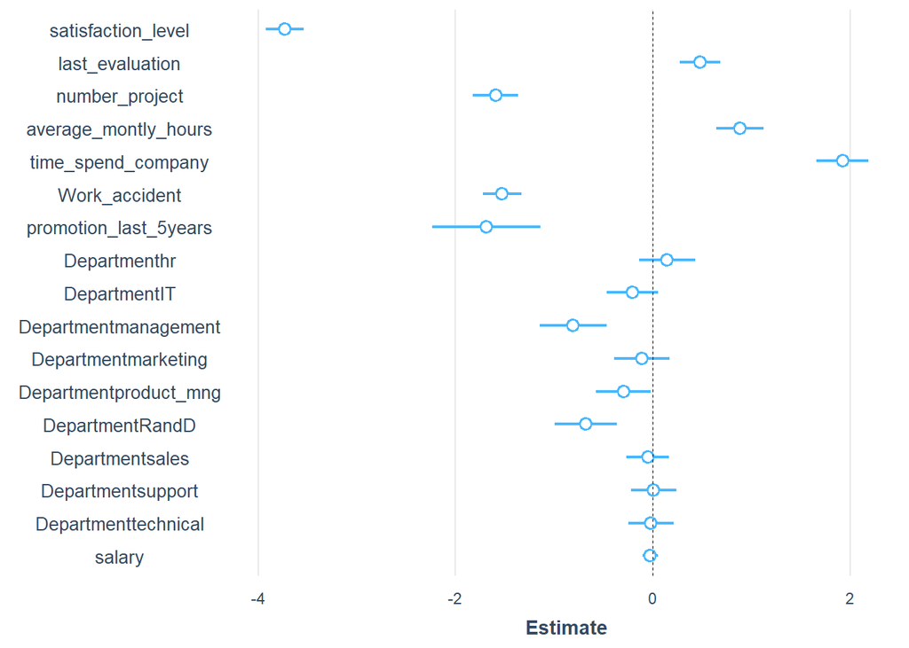

```r
plot_summs(modelLogistic)
```

## 7. Apply at least 2 Clustering Techniques

### 7.A. Describe the reason you choose those 2 techniques.

In the result of PCA’s, We observed that our dataset contains mostly similar values that are close to each other. In based of a distance measure we chose to use K-means to group our data into clusters. In terms of clustering large number of data points like our dataset, We choose Hierarchical clustering to get better results in larger sets.

### 7.1 K-Means Algorithm Application

#### 7.1.A.X Use appropriate functions and arguments

```r
summary(datapca)
```

```
## Importance of components:
##                           PC1    PC2    PC3    PC4    PC5     PC6     PC7
## Standard deviation     1.3642 1.2102 1.0304 0.9995 0.9775 0.91951 0.84196
## Proportion of Variance 0.2068 0.1627 0.1180 0.1110 0.1062 0.09394 0.07877
## Cumulative Proportion  0.2068 0.3695 0.4875 0.5985 0.7046 0.79858 0.87735
##                            PC8     PC9
## Standard deviation     0.79150 0.69094
## Proportion of Variance 0.06961 0.05304
## Cumulative Proportion  0.94696 1.00000
```

We use the PCA results for K-Means Clustering.

#### 7.1.B Use visualization techniques

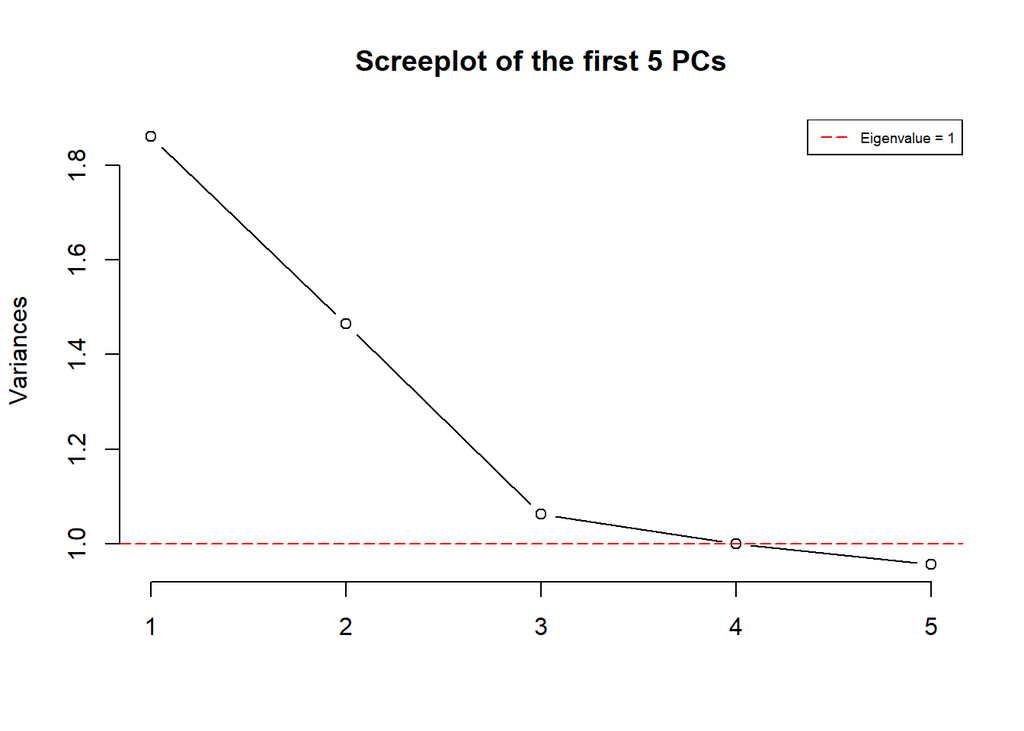

```r
screeplot(datapca, type = "l", npcs = 5, main = "Screeplot of the first 5 PCs")
abline(h = 1, col="red", lty="longdash")
legend("topright", legend=c("Eigenvalue = 1"),
       col=c("red"), lty=5, cex=0.6)
```

The graph shows first 5 PCs. There are 3 PCs above the line so we can make 3 clusters.

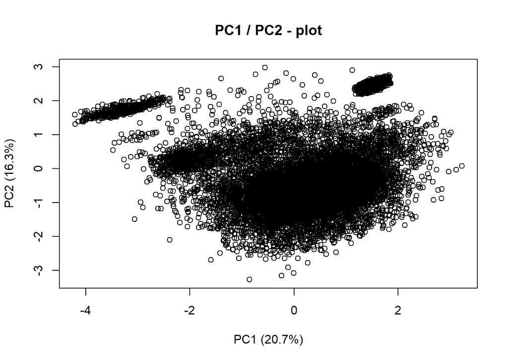

```r
plot(datapca$x[,1],datapca$x[,2], xlab="PC1 (20.7%)", ylab = "PC2 (16.3%)", main = "PC1 / PC2 - plot")
```

This is PC1 and PC2 plot. We will use this plot to visualize our clusters.

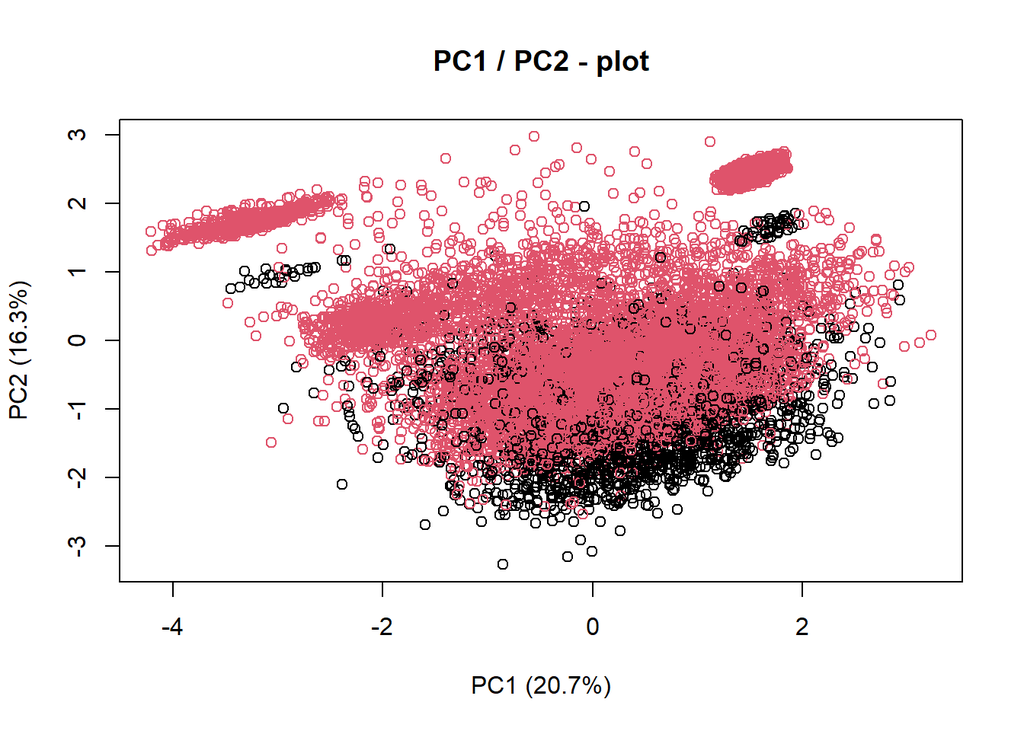

```r
set.seed(101)
km <- kmeans(data[,1:8,10], 2)
plot(datapca$x[,1],datapca$x[,2], xlab="PC1 (20.7%)",
     ylab = "PC2 (16.3%)",
     main = "PC1 / PC2 - plot",
     col=km$cluster)
```

If we use 2 clusters the plot would look like that. The difference between two clusters is not that noticable.

```r
km$centers
```

```
##   satisfaction_level last_evaluation number_project average_montly_hours
## 1          0.6135455       0.5517880      0.3577686            0.4851325
## 2          0.5679486       0.5571902      0.3610912            0.4918627
##   time_spend_company Work_accident       left promotion_last_5years
## 1          0.1882204             1 0.07791609            0.03503919
## 2          0.1871200             0 0.26515978            0.01893998
```

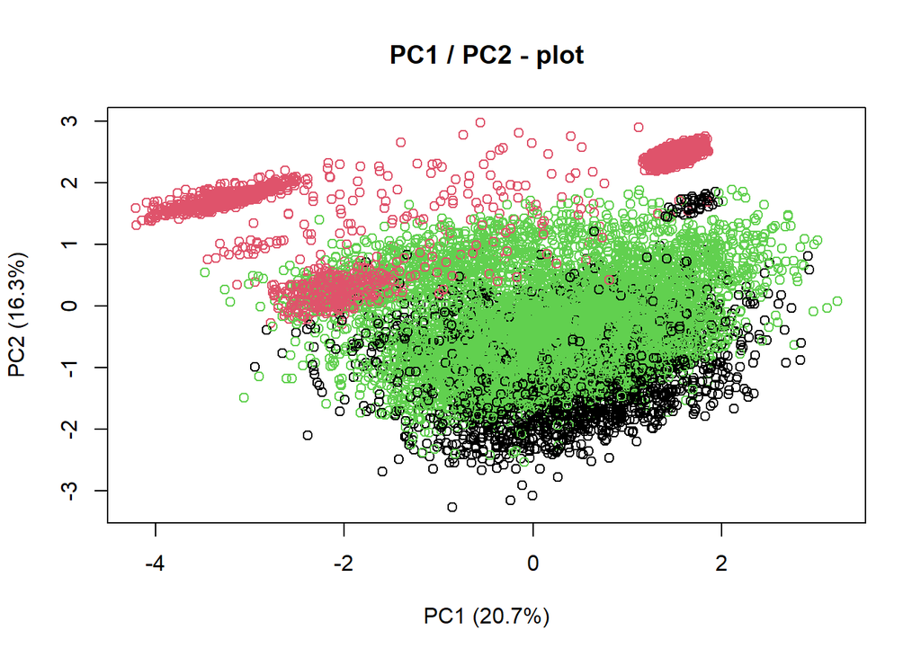

```r
set.seed(102)
km <- kmeans(data[,1:8,10], 3)
plot(datapca$x[,1],datapca$x[,2], xlab="PC1 (20.7%)",
     ylab = "PC2 (16.3%)",
     main = "PC1 / PC2 - plot",
     col=km$cluster)
```

This is the plot when we make 3 clusters.

```r
table(km$cluster, data$left)
```

```
##
##        0    1
##   1 2000  121
##   2    0 3450
##   3 9428    0
```

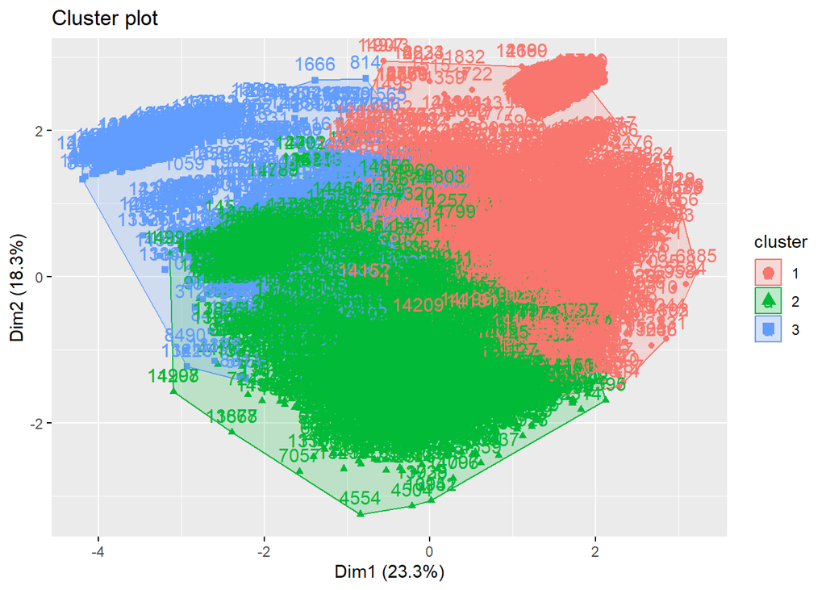

```r
km <- kmeans(data[,1:5], 3)
fviz_cluster(km, data = data[,1:8,10])
```

Here is a better visualization of 3 clusters. As we can see this is more pleasant. Also we have a table output. 1 represents employees who left the company. In cluster two there are employees who left the company, in cluster 3 there are only the employees who still works there.

#### 7.1.C Final comments

The Department column was not included when the PCA was performed to the data. The center points were established, and k was set to 3. The center points were clustered using the kmeans algorithm, which produced the blue, red, and green clusters. The graphic illustrates the visualization of these clusters.

### 7.2. Hierarchical Algorithm Application

#### 7.2.A. Use appropriate functions and arguments

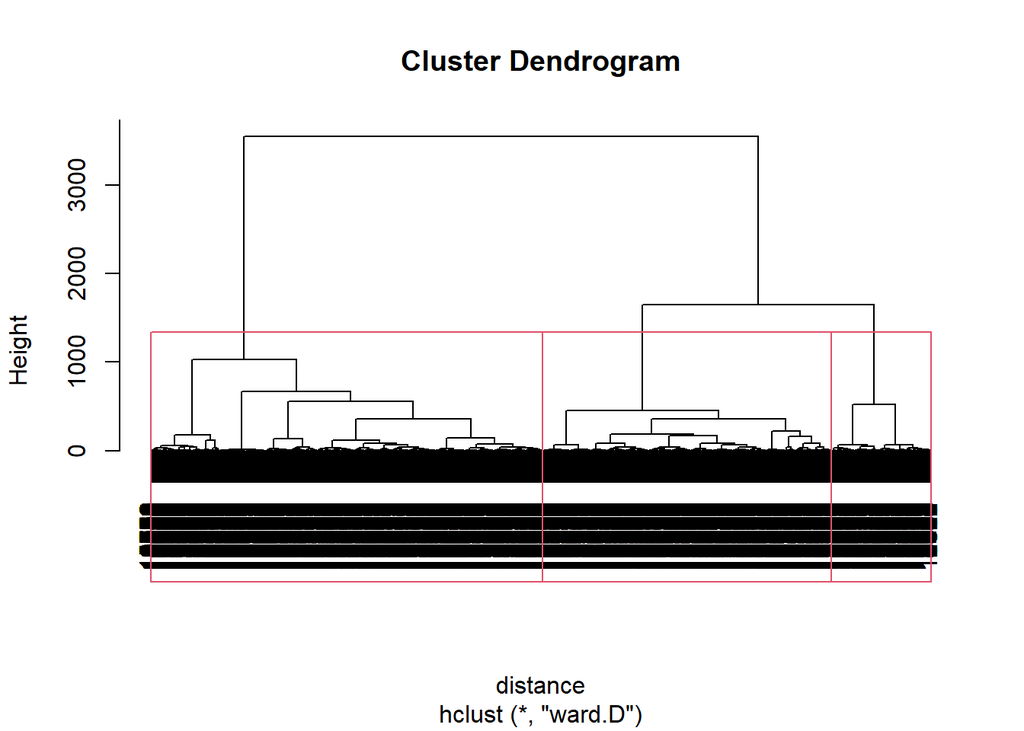

```r
distance <- dist(data[, c(1:6, 8, 10)], method = "euclidean")
cluster_data <- hclust(distance, method = "ward.D")
plot(cluster_data)
rect.hclust(cluster_data, k=3)
```

Each leaf at the bottom of the dendrogram represents an observation in the original dataset. As we move up the dendrogram from the bottom, observations that are similar to each other are fused together into a branch. We made 3 clusters with hierarchical clustering.

#### 7.2.B. Use visualization techniques

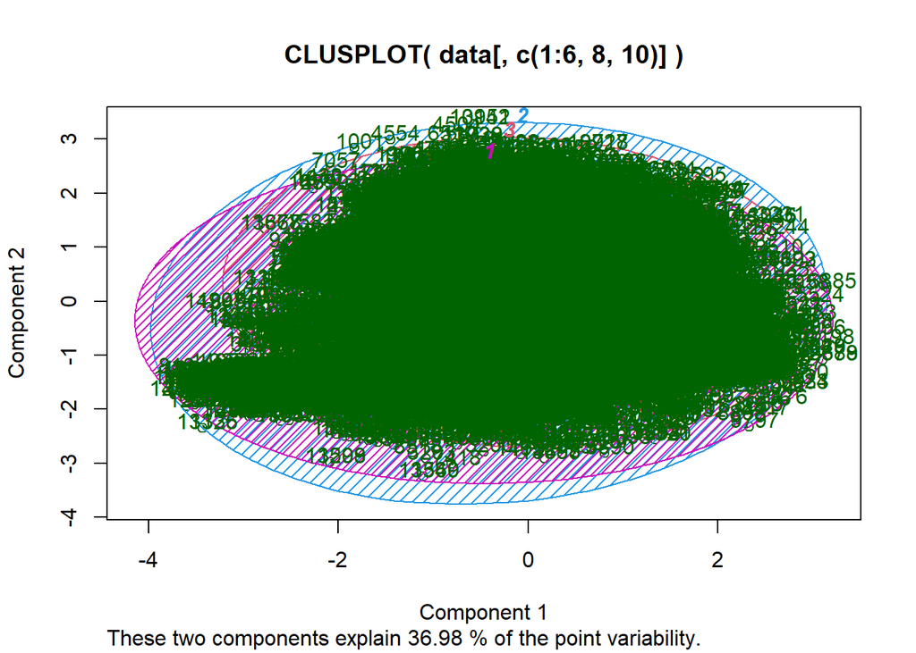

```r
sm_hc <- cutree(cluster_data, 3)
clusplot(data[, c(1:6, 8, 10)], clus = sm_hc, lines = 0, shade = TRUE, color = TRUE, labels = 2, plotchar = FALSE, span = TRUE)
```

In this plot we can see the 3 clusters. Since we have a large data, the numbers do not really show.

#### 7.2.C. Final comments

We performed hierarchical clustering on our data set. We calculated the distance matrix using Euclidean distance and used this matrix to perform hierarchical clustering. We then plotted the resulting clustering object and drew rectangles around the clusters which were specified as 3. We also cut the hierarchical clustering tree into 3 clusters and created a plot showing these clusters, where the shading and color coding indicated the membership of each point.

### 7.B. Compare the results you have found in 7.1 and 7.2

We made 3 clusters in each techniques. We can see by the visualization results, k-means clustering was more successful.

## 8. Apply at least 2 Classification Techniques.

### 8.A. Describe the reason you choose those 2 techniques.

We’ll use the output of step 6 here, so We’re skipping 8.2 here.

Decision tree classification is a powerful and popular machine learning algorithm that is used to classify data.It is a simple yet powerful approach that can be used to build complex models. Decision tree classification is advantageous because it is easy to interpret and can handle both numerical and categorical data. Additionally, decision trees can be used to perform feature selection, which is useful for identifying important features from a large dataset.

### 8.1. Decision Tree Algorithm Application

#### 8.1.A Use appropriate functions and arguments

```r
model <- rpart(formula = left ~ ., data = trainSet)
prob2 <- predict(model , testSet ,type="vector")
```

After creating model, we check the levels are they even or not.

```r
levels(as.factor(prob2))
```

```
## [1] "0"                  "0.014986568641312"  "0.046031746031746"
## [4] "0.0654205607476635" "0.0764227642276423" "0.0833333333333333"
## [7] "0.918774966711052"  "0.969507427677873"  "1"
```

```r
levels(as.factor(testSet$left))
```

```
## [1] "0" "1"
```

```r
pred2 <- ifelse(prob > 0.36, 1, 0)
```

If the prediction value higher from 0.36 turn into 1 else turn into 0

```r
matrixLog2 <- confusionMatrix(
  factor(pred2, levels = c(0,1)),
  factor(testSet$left, levels = c(0,1)))

matrixLog2
```

```
## Confusion Matrix and Statistics
##
##           Reference
## Prediction    0    1
##          0 1949  251
##          1  332  467
##
##                Accuracy : 0.8056
##                  95% CI : (0.791, 0.8196)
##     No Information Rate : 0.7606
##     P-Value [Acc > NIR] : 1.956e-09
##
##                   Kappa : 0.4861
##
##  Mcnemar's Test P-Value : 0.0009221
##
##             Sensitivity : 0.8544
##             Specificity : 0.6504
##          Pos Pred Value : 0.8859
##          Neg Pred Value : 0.5845
##              Prevalence : 0.7606
##          Detection Rate : 0.6499
##    Detection Prevalence : 0.7336
##       Balanced Accuracy : 0.7524
##
##        'Positive' Class : 0
##
```

#### 8.1.B Use visualization techniques

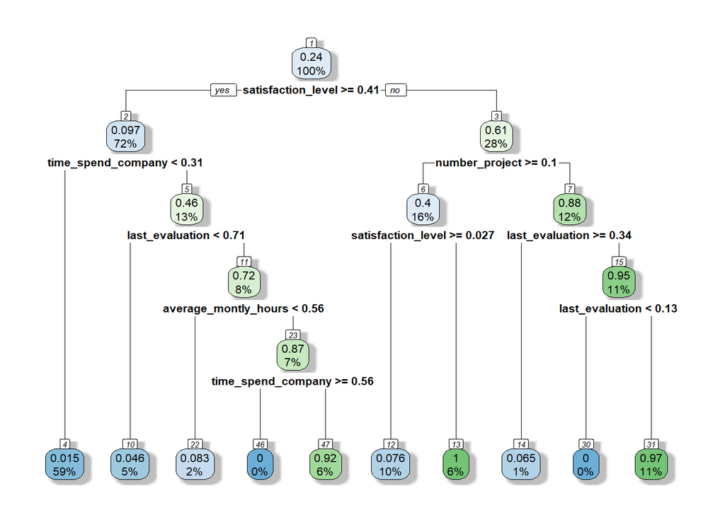

```r
rpart.plot(model, box.palette="BuGn", shadow.col="gray", nn=TRUE)
```